# Lab 2

2023-09-19

#### Downloading data

Use `getSymbols` to get data from yahoo or Google (default is yahoo)

```r
getSymbols("SPY")
```

```
## [1] "SPY"
```

You can find the ‘symbols’ or ‘tickers’ here: https://finance.yahoo.com/lookup

Some popular tickers:

- SPY is SPDR S&P 500 ETF Trust ticker symbol
- QQQ is Invesco QQQ Trust ticker symbol
- ^GSPC is S&P500
- PFE is Pfizer
- F is Ford

There are several ways to see what is inside the data.

For example:

```r
head(SPY)
```

```
##            SPY.Open SPY.High SPY.Low SPY.Close SPY.Volume SPY.Adjusted
## 2007-01-03   142.25   142.86  140.57    141.37   94807600     102.2650
## 2007-01-04   141.23   142.05  140.61    141.67   69620600     102.4820
## 2007-01-05   141.33   141.40  140.38    140.54   76645300     101.6646
## 2007-01-08   140.82   141.41  140.25    141.19   71655000     102.1348
## 2007-01-09   141.31   141.60  140.40    141.07   75680100     102.0480
## 2007-01-10   140.58   141.57  140.30    141.54   72428000     102.3880
```

```r
tail(SPY)
```

```
##            SPY.Open SPY.High SPY.Low SPY.Close SPY.Volume SPY.Adjusted
## 2023-09-11   448.24   448.77  446.47    448.45   60180100     446.8737
## 2023-09-12   446.95   448.53  445.39    445.99   67565400     444.4224
## 2023-09-13   446.22   447.71  445.08    446.51   60199300     444.9406
## 2023-09-14   449.07   451.08  447.72    450.36   83430800     448.7770
## 2023-09-15   447.14   447.48  442.92    443.37  111761400     443.3700
## 2023-09-18   443.05   444.97  442.56    443.63   55752200     443.6300
```

If you wish to only import at a certain date e.g.,. 2023-01-01 to 2023-09-19, we can restrict the set the data to download:

```r
getSymbols("SPY", from='2023-01-01',to='2023-09-19')
```

```
## [1] "SPY"
```

Alternatively, load the whole series and restrict using xts function `first()` or `last()`:

```r
getSymbols("SPY")
```

```
## [1] "SPY"
```

```r
SPY_first <- first(SPY,'1 year')
head(SPY_first)
```

```
##            SPY.Open SPY.High SPY.Low SPY.Close SPY.Volume SPY.Adjusted
## 2007-01-03   142.25   142.86  140.57    141.37   94807600     102.2650
## 2007-01-04   141.23   142.05  140.61    141.67   69620600     102.4820
## 2007-01-05   141.33   141.40  140.38    140.54   76645300     101.6646
## 2007-01-08   140.82   141.41  140.25    141.19   71655000     102.1348
## 2007-01-09   141.31   141.60  140.40    141.07   75680100     102.0480
## 2007-01-10   140.58   141.57  140.30    141.54   72428000     102.3880
```

```r
SPY_last <- last(SPY,'1 year')
head(SPY_last)
```

```
##            SPY.Open SPY.High SPY.Low SPY.Close SPY.Volume SPY.Adjusted
## 2023-01-03   384.37   386.43  377.83    380.82   74850700     376.6396
## 2023-01-04   383.18   385.88  380.00    383.76   85934100     379.5473
## 2023-01-05   381.72   381.84  378.76    379.38   76970500     375.2154
## 2023-01-06   382.61   389.25  379.41    388.08  104189600     383.8199
## 2023-01-09   390.37   393.70  387.67    387.86   73978100     383.6023
## 2023-01-10   387.25   390.65  386.27    390.58   65358100     386.2924
```

You can also import several stocks at the same time by using a vector:

```r
getSymbols(c('SPY','^GSPC','PFE'))
```

```
## [1] "SPY"  "GSPC" "PFE"
```

Alternatively, assign a vector of stocks and import based on the vector:

```r
stock_list <- c('SPY','^GSPC','PFE')
getSymbols(stock_list, from='2023-01-01',to='2023-09-19')
```

```
## [1] "SPY"  "GSPC" "PFE"
```

`Quantmod` draw nice charts using `chartSeries()` (https://www.quantmod.com/examples/charting/):

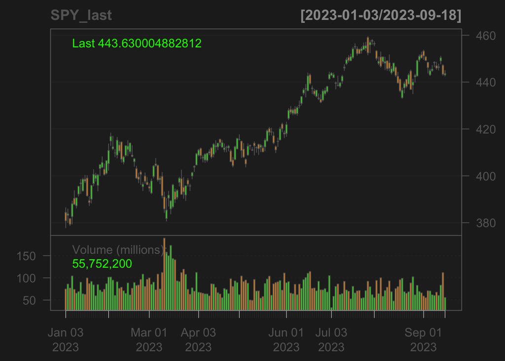

```r
chartSeries(SPY_last)
```

You can select to display a shorter time-interval using the argument `subset`.

Also note that the option `theme` should be set to be `chartTheme(‘white’)` if intended for printing. The default option `chartTheme(‘black’)` is not printer-friendly.

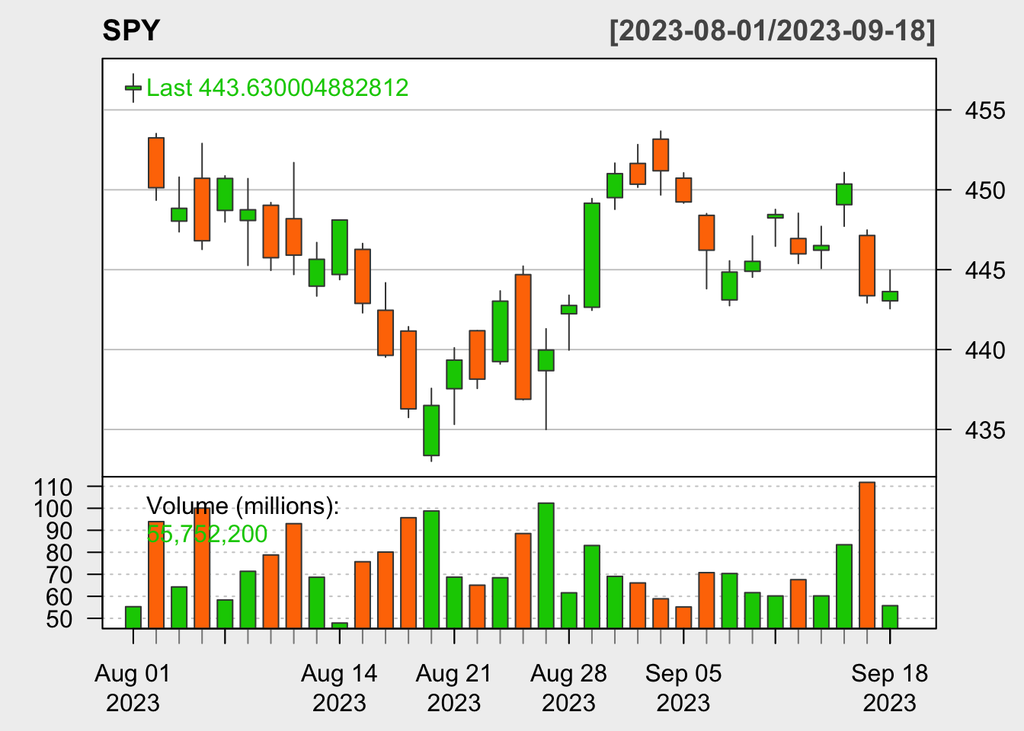

```r
chartSeries(SPY,
            subset='2023-08::2023-09',
            theme=chartTheme('white'))
```

Use `TA=NULL’ to omit displaying the trade volume.

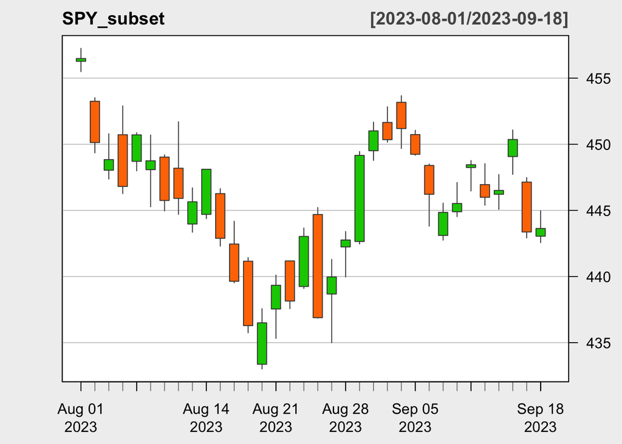

```r
SPY_subset <- SPY['2023-08::2023-09']
chartSeries(SPY_subset,
            TA=NULL,
            theme=chartTheme('white'))
```

To add the ‘Open to Close’ price change, use the `quantmod` function `addTA` which allows to display additional chart and `OpCl` function which computes the daily difference between opening and closing stock prices:

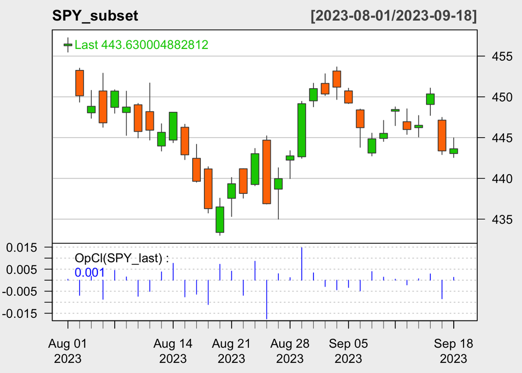

```r
addTA(OpCl(SPY_last),col='blue', type='h')
```

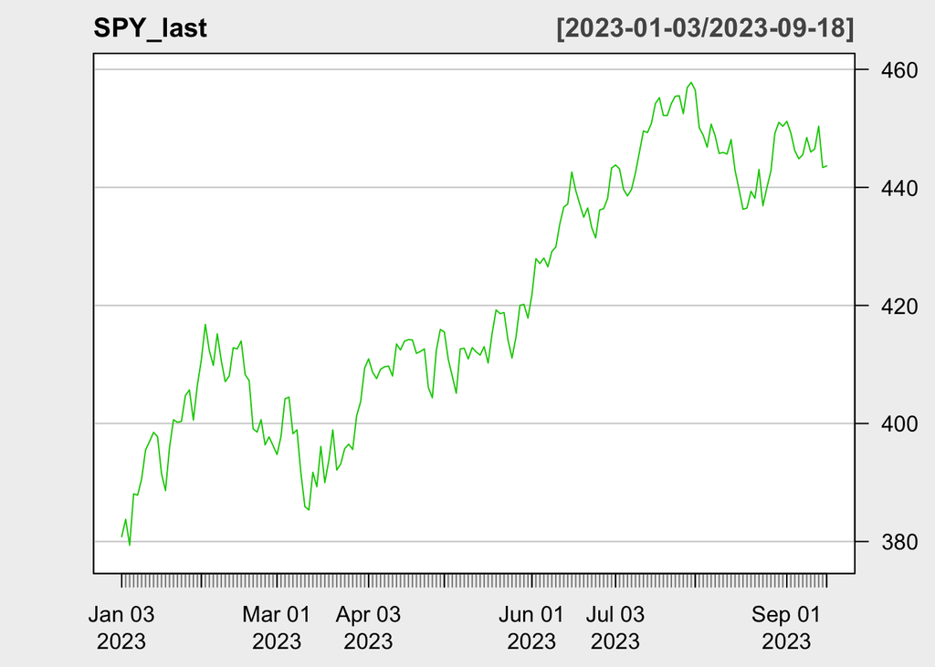

```r
chartSeries(SPY_last, type="line", TA=NULL, theme=chartTheme('white'))
```

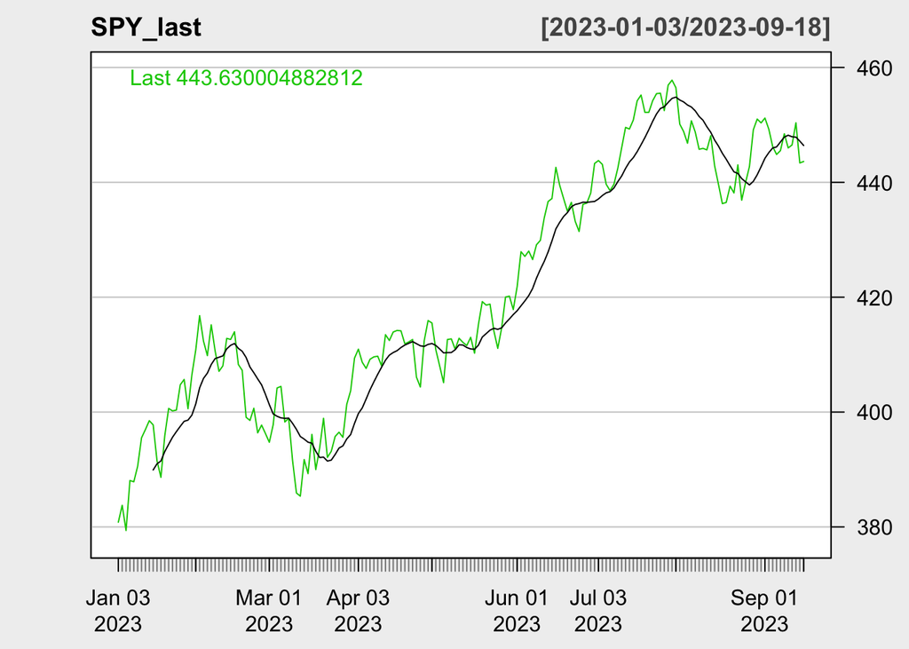

```r
addSMA(n=10,col = "black")
```

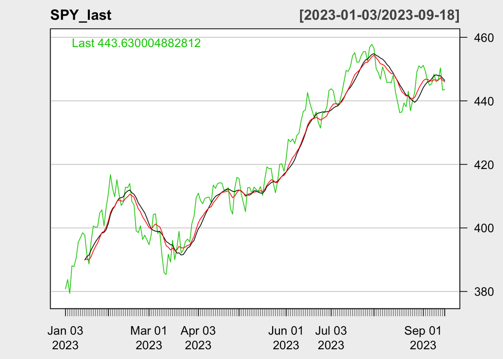

```r
addEMA(n=10,col = "red")
```

To extract columns, we use `Op`, `Hi`, `Lo`, `Cl`, `Vo` and `Ad`:

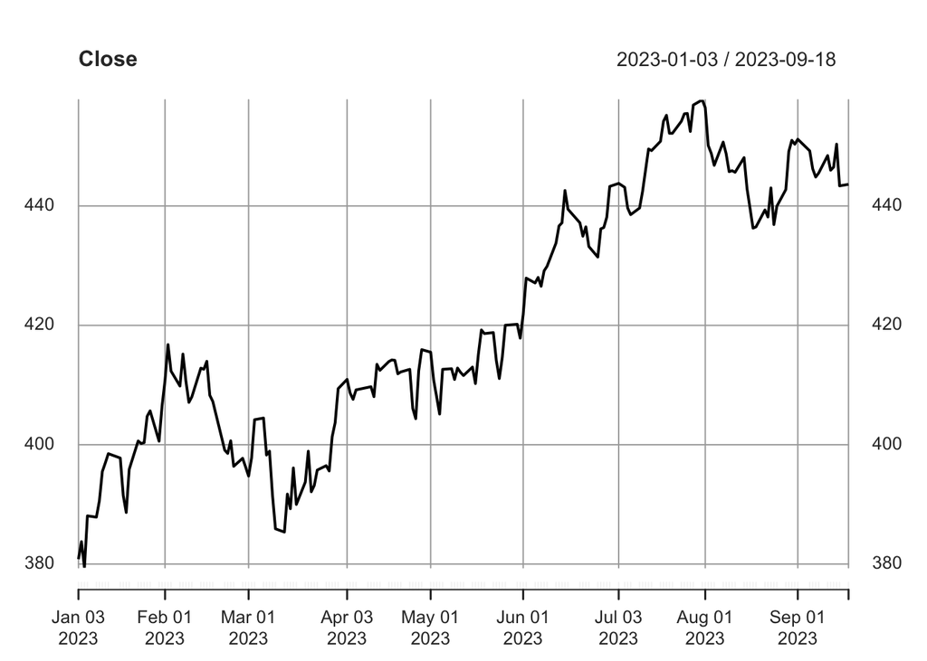

```r
Open <- Op(SPY_last)   #Open Price
High <- Hi(SPY_last)    # High price
Low <- Lo(SPY_last)  # Low price
Close<- Cl(SPY_last)   #Close Price
Volume <- Vo(SPY_last)   #Volume
AdjClose <- Ad(SPY_last) # Adjusted close

plot(Close)
```

```r
head(Close)
```

```
##            SPY.Close
## 2023-01-03    380.82
## 2023-01-04    383.76
## 2023-01-05    379.38
## 2023-01-06    388.08
## 2023-01-09    387.86
## 2023-01-10    390.58
```